# 94-842 Programming R for Analytics

Final Project

Animish Andraskar

Submission Date: 13 Dec 2019

# Project overview

This R Markdown file contains the end to end data analysis done on the “Cleveland Heart Disease” data set. In this project, we are trying to identify key factors or predictors which will help us determine what kinds of health attributes indicate the risk of heart disease.

When the data was generated, there were a total of 76 attributes captured. But finally, 14 important attributes were published by the researchers. We will also use the same 14 attributes or the dependent variables for our analysis. The variables are:

- `age`: age in years
- `sex`: (1 = male; 0 = female)
- `cp`: chest pain type (0 = typical angina; 1 = atypical angina; 2 = non-anginal pain; 3 = asymptomatic)
- `trestbps`: resting blood pressure (in mm Hg on admission to the hospital)
- `chol`: serum cholestoral in mg/dl
- `fbs`: fasting blood sugar > 120 mg/dl (1 = true; 0 = false)
- `restecg`: resting electrocardiographic results
- `thalach`: maximum heart rate achieved
- `exang`: exercise induced angina (1 = yes; 0 = no)
- `oldpeak`: ST depression induced by exercise relative to rest
- `slope`: the slope of the peak exercise ST segment (0 = upsloping; 1 = flat, 2 = downsloping)
- `ca`: number of major vessels (0-3) colored by flourosopy
- `thal`: A blood disorder called thalassemia (0 = unknown; 1 = normal; 2 = fixed defect; 3 = reversable defect)

The target variable or the “labels” for heart disease are stored under “target” column. Initially this column had up to 4 levels of heart disease, but for simplification the column has been made binary. This will be our dependent variable in the analysis.

- `target`: presence of heart disease (0 = yes; 1 = no)

In our analysis, we will first understand what all information the data set contains with the help of R. Then we will build different predictive models for our predictions and compare them against each other. Ultimately, we will choose the best performing model or a combination of models to build our final prediction engine. Let’s go!

(**Original publishers of the dataset** - https://archive.ics.uci.edu/ml/datasets/Heart+Disease)

# Data exploration

### File reading

Read the file.

```r
# Make sure the cas is in the same folder as this notebook and that folder is set as working directory
dataset <- read.csv("heart.csv", encoding="UTF-8-BOM")
# shuffle rows so that we see a good mix of different values in the output
dataset <- dataset[sample(nrow(dataset)), ]
head(dataset)
```

```
##     Ã¯..age sex cp trestbps chol fbs restecg thalach exang oldpeak slope ca
## 57      48   1  0      122  222   0       0     186     0     0.0     2  0
## 213     39   1  0      118  219   0       1     140     0     1.2     1  0
## 173     58   1  1      120  284   0       0     160     0     1.8     1  0
## 51      51   0  2      130  256   0       0     149     0     0.5     2  0
## 283     59   1  2      126  218   1       1     134     0     2.2     1  1
## 282     52   1  0      128  204   1       1     156     1     1.0     1  0
##     thal target
## 57     2      1
## 213    3      0
## 173    2      0
## 51     2      1
## 283    1      0
## 282    0      0
```

The dataset has **303** rows and **14** columns.

Let’s have a look at the columns read from the data set and make them more user friendly, if there is a scope.

```r
names(dataset)
```

```
##  [1] "Ã¯..age"   "sex"      "cp"       "trestbps" "chol"     "fbs"
##  [7] "restecg"  "thalach"  "exang"    "oldpeak"  "slope"    "ca"
## [13] "thal"     "target"
```

Age column needs renaming.

```r
# rename age column
names(dataset)[1] <- "age"
# let's check the column names again
names(dataset)
```

```
##  [1] "age"      "sex"      "cp"       "trestbps" "chol"     "fbs"
##  [7] "restecg"  "thalach"  "exang"    "oldpeak"  "slope"    "ca"
## [13] "thal"     "target"
```

### Data summary

Have a look at the summary and the structure of the dataset and make sure we have all the variables.

```r
summary(dataset)
```

```
##       age             sex               cp           trestbps
##  Min.   :29.00   Min.   :0.0000   Min.   :0.000   Min.   : 94.0
##  1st Qu.:47.50   1st Qu.:0.0000   1st Qu.:0.000   1st Qu.:120.0
##  Median :55.00   Median :1.0000   Median :1.000   Median :130.0
##  Mean   :54.37   Mean   :0.6832   Mean   :0.967   Mean   :131.6
##  3rd Qu.:61.00   3rd Qu.:1.0000   3rd Qu.:2.000   3rd Qu.:140.0
##  Max.   :77.00   Max.   :1.0000   Max.   :3.000   Max.   :200.0
##       chol            fbs            restecg          thalach
##  Min.   :126.0   Min.   :0.0000   Min.   :0.0000   Min.   : 71.0
##  1st Qu.:211.0   1st Qu.:0.0000   1st Qu.:0.0000   1st Qu.:133.5
##  Median :240.0   Median :0.0000   Median :1.0000   Median :153.0
##  Mean   :246.3   Mean   :0.1485   Mean   :0.5281   Mean   :149.6
##  3rd Qu.:274.5   3rd Qu.:0.0000   3rd Qu.:1.0000   3rd Qu.:166.0
##  Max.   :564.0   Max.   :1.0000   Max.   :2.0000   Max.   :202.0
##      exang           oldpeak         slope             ca
##  Min.   :0.0000   Min.   :0.00   Min.   :0.000   Min.   :0.0000
##  1st Qu.:0.0000   1st Qu.:0.00   1st Qu.:1.000   1st Qu.:0.0000
##  Median :0.0000   Median :0.80   Median :1.000   Median :0.0000
##  Mean   :0.3267   Mean   :1.04   Mean   :1.399   Mean   :0.7294
##  3rd Qu.:1.0000   3rd Qu.:1.60   3rd Qu.:2.000   3rd Qu.:1.0000
##  Max.   :1.0000   Max.   :6.20   Max.   :2.000   Max.   :4.0000
##       thal           target
##  Min.   :0.000   Min.   :0.0000
##  1st Qu.:2.000   1st Qu.:0.0000
##  Median :2.000   Median :1.0000
##  Mean   :2.314   Mean   :0.5446
##  3rd Qu.:3.000   3rd Qu.:1.0000
##  Max.   :3.000   Max.   :1.0000
```

```r
str(dataset)
```

```
## 'data.frame':    303 obs. of  14 variables:
##  $ age     : int  48 39 58 51 59 52 65 56 57 55 ...
##  $ sex     : int  1 1 1 0 1 1 0 0 1 0 ...
##  $ cp      : int  0 0 1 2 2 0 2 0 0 1 ...
##  $ trestbps: int  122 118 120 130 126 128 155 134 110 132 ...
##  $ chol    : int  222 219 284 256 218 204 269 409 201 342 ...
##  $ fbs     : int  0 0 0 0 1 1 0 0 0 0 ...
##  $ restecg : int  0 1 0 0 1 1 1 0 1 1 ...
##  $ thalach : int  186 140 160 149 134 156 148 150 126 166 ...
##  $ exang   : int  0 0 0 0 0 1 0 1 1 0 ...
##  $ oldpeak : num  0 1.2 1.8 0.5 2.2 1 0.8 1.9 1.5 1.2 ...
##  $ slope   : int  2 1 1 2 1 1 2 1 1 2 ...
##  $ ca      : int  0 0 0 0 1 0 0 2 0 0 ...
##  $ thal    : int  2 3 2 2 1 0 2 3 1 2 ...
##  $ target  : int  1 0 0 1 0 0 1 0 1 1 ...
```

```r
cat.vars <- c("sex", "cp", "ca", "fbs", "restecg", "exang", "slope", "thal", "target")
num.vars <- setdiff(names(dataset), cat.vars)
```

We can see that all the variables we need are present in the file. However, there is one thing we need to fix, and that is the variable types. Variables like sex, cp, restecg, fbs etc. are categorical but characterized as int. We will fix that below.

### Null value check

Let’s check if any variable has null values.

```r
# Traverse each column and check for null values
for(name in names(dataset)) {
  print(paste(name, "column contains", sum(is.na(dataset[, name])), "null values"))
}
```

```
## [1] "age column contains 0 null values"
## [1] "sex column contains 0 null values"
## [1] "cp column contains 0 null values"
## [1] "trestbps column contains 0 null values"
## [1] "chol column contains 0 null values"
## [1] "fbs column contains 0 null values"
## [1] "restecg column contains 0 null values"
## [1] "thalach column contains 0 null values"
## [1] "exang column contains 0 null values"
## [1] "oldpeak column contains 0 null values"
## [1] "slope column contains 0 null values"
## [1] "ca column contains 0 null values"
## [1] "thal column contains 0 null values"
## [1] "target column contains 0 null values"
```

We can see that there are no null values in any column.

### First glance at data distribution

Look at the distribution of each column.

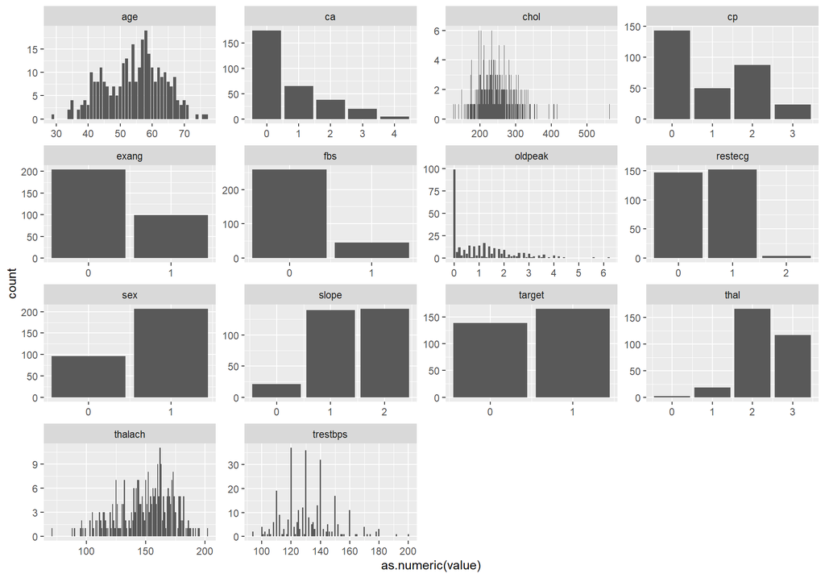

```r
# plot histograms of all variables to see how they are distributed
dataset %>%
  # gather columns into key value pairs
  gather() %>%
  # plot histogram with each graph having independent axes
  ggplot(aes(as.numeric(value))) + facet_wrap(~ key, scales = "free") + geom_bar() + scale_x_continuous(breaks = function(x, n = 5) pretty(x, n)[pretty(x, n) %% 1 == 0] )
```

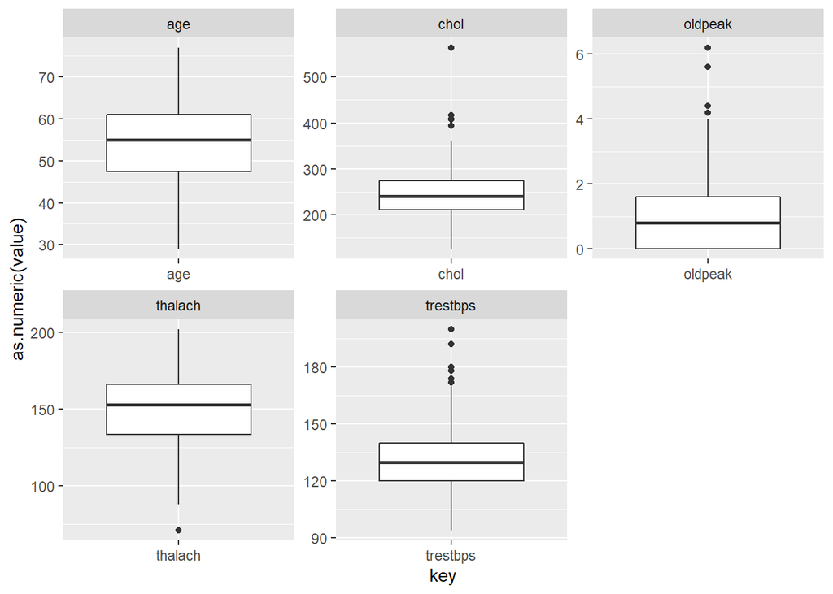

```r
# plot boxplot of all numeric variables to see how their values are distributed
dataset[, num.vars] %>%
  # gather columns into key value pairs
  gather() %>%
  # generate boxplot with each graph having independent axes
  ggplot(aes(key, as.numeric(value))) + facet_wrap(~ key, scales = "free") + geom_boxplot()
```

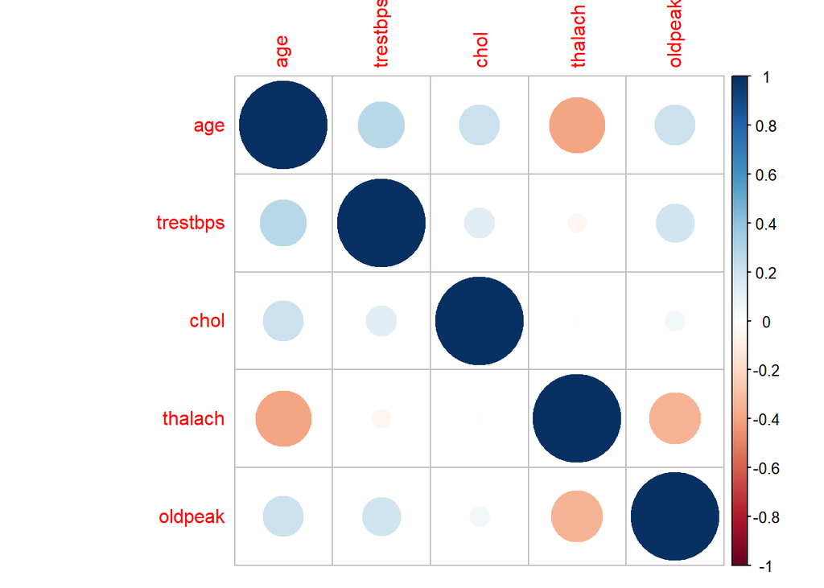

```r
# correlation plot
corrdata <- cor(dataset[, num.vars])
corrplot(corrdata)
```

```r
# correlation values
round(cor(dataset[, num.vars]), 2)
```

```
##            age trestbps  chol thalach oldpeak
## age       1.00     0.28  0.21   -0.40    0.21
## trestbps  0.28     1.00  0.12   -0.05    0.19
## chol      0.21     0.12  1.00   -0.01    0.05
## thalach  -0.40    -0.05 -0.01    1.00   -0.34
## oldpeak   0.21     0.19  0.05   -0.34    1.00
```

Very first thing we notice is that there are outliers in all the numeric columns except `age`. We need to treat outliers by removing them.

Second thing to notice is that moderate collinearity exists in `thalach ~ age` (correlation coefficient -0.4) and `thalach ~ oldpeak` (correlation coefficient -0.34) pairs. We will deal with this as well.

Lastly, we must notice is that the dependent variable `target` is a bit imbalanced with 1 slightly overpowering 0. We need to rebalance that as well.

# Data treatment

Let’s treat our data based on our observations in the previous step.

### Fixing column types

We saw above that certain columns, which are supposed to be categorical are treated as numeric. We need to fix their data types.

```r
for(var in cat.vars) {
  dataset[[var]] <- factor(dataset[[var]])
}
str(dataset)
```

```
## 'data.frame':    303 obs. of  14 variables:
##  $ age     : int  48 39 58 51 59 52 65 56 57 55 ...
##  $ sex     : Factor w/ 2 levels "0","1": 2 2 2 1 2 2 1 1 2 1 ...
##  $ cp      : Factor w/ 4 levels "0","1","2","3": 1 1 2 3 3 1 3 1 1 2 ...
##  $ trestbps: int  122 118 120 130 126 128 155 134 110 132 ...
##  $ chol    : int  222 219 284 256 218 204 269 409 201 342 ...
##  $ fbs     : Factor w/ 2 levels "0","1": 1 1 1 1 2 2 1 1 1 1 ...
##  $ restecg : Factor w/ 3 levels "0","1","2": 1 2 1 1 2 2 2 1 2 2 ...
##  $ thalach : int  186 140 160 149 134 156 148 150 126 166 ...
##  $ exang   : Factor w/ 2 levels "0","1": 1 1 1 1 1 2 1 2 2 1 ...
##  $ oldpeak : num  0 1.2 1.8 0.5 2.2 1 0.8 1.9 1.5 1.2 ...
##  $ slope   : Factor w/ 3 levels "0","1","2": 3 2 2 3 2 2 3 2 2 3 ...
##  $ ca      : Factor w/ 5 levels "0","1","2","3",..: 1 1 1 1 2 1 1 3 1 1 ...
##  $ thal    : Factor w/ 4 levels "0","1","2","3": 3 4 3 3 2 1 3 4 2 3 ...
##  $ target  : Factor w/ 2 levels "0","1": 2 1 1 2 1 1 2 1 2 2 ...
```

### Handling outliers

To make sure that the model/s we build are optimized and accurate, we will remove rows with outliers.

```r
total.rows.removed = 0
for(var in num.vars) {
  rows.deleted <- nrow(dataset[which(dataset[, var] %in% boxplot.stats(dataset[, var])$out),])
  total.rows.removed = total.rows.removed + rows.deleted
  dataset <- dataset[which(!dataset[, var] %in% boxplot.stats(dataset[, var])$out),]
  print(paste0(rows.deleted, " rows deleted for having outlying values of ", var))
}
```

```
## [1] "0 rows deleted for having outlying values of age"
## [1] "9 rows deleted for having outlying values of trestbps"
## [1] "5 rows deleted for having outlying values of chol"
## [1] "1 rows deleted for having outlying values of thalach"
## [1] "4 rows deleted for having outlying values of oldpeak"
```

Total rows removed are **19**.

### Multicollinearity removal

Earlier, we observed a moderate collinearity in `thalach ~ age` (coefficient -0.4) and `thalach ~ oldpeak` (coefficient -0.34) variable pairs. These two correlations are quite obvious.

- `thalach` is maximum heart rate achieved (HRmax). The formula for calculating target HRmax is `0.9 * (220 - age)`. So, as age increases, HRmax decreases. (Reference: http://www.turnstep.com/Faq/heartrate.html)
- Similarly, as HRmax decreases, `oldpeak` (achieved response to stress test) increases as it becomes easy to displace J point below the baseline with decreased heart rate. (Reference: https://www.ncbi.nlm.nih.gov/books/NBK459364/)

Hence, `thalach` provides redundant information and it would be wise to remove it from the analysis.

```r
# remove thalach column
dataset <- dataset[, !(names(dataset) == "thalach")]
# update numeric variables list
num.vars <- num.vars[num.vars != 'thalach']
```

### Data rebalancing

Let’s now identify the difference between occurrances of 0’s and 1’s in `target`, and fix the imbalance.

```r
zeros = sum(dataset$target == 0)
ones = sum(dataset$target == 1)
paste("Number of 0's in target variable:", zeros)
```

```
## [1] "Number of 0's in target variable: 125"
```

```r
paste("Number of 1's in target variable:", ones)
```

```
## [1] "Number of 1's in target variable: 159"
```

```r
# let's store the difference dynamically
target.imbalance = max(zeros, ones) - min(zeros, ones)

if(max(zeros, ones) == zeros) { # Zeros overpower
  print(paste0("Zeros overpower ones with a difference of ", target.imbalance,
               ". Hence we will add some random samples of rows with target 1 to the dataset"))
  # More samples of 1's need to be added
  sampled.rows <- sample_n(dataset[which(dataset$target == 1),], target.imbalance)
  sampled = "ones"
} else if(max(zeros, ones) == ones) { # Ones overpower
  print(paste0("Ones overpower zeros with a difference of ", target.imbalance,
               ". Hence we will add some random samples of rows with target 0 to the dataset"))
  # More samples of 0's need to be added
  sampled.rows <- sample_n(dataset[which(dataset$target == 0),], target.imbalance)
  sampled = "zeros"
} else { # No imbalance
  "No imbalance"
  sampled.rows <- NULL
  sampled = "no rows"
}
```

```
## [1] "Ones overpower zeros with a difference of 34. Hence we will add some random samples of rows with target 0 to the dataset"
```

```r
# Combine all rows
dataset <- rbind(dataset, sampled.rows)
```

We have added 34 randomly sampled rows with target zeros to the data. Both zeros and ones have 159 observations, and the total number of rows now is 318.

### Treated data distribution

Now that we have balanced the data, let’s look at the distribution of the data columns again.

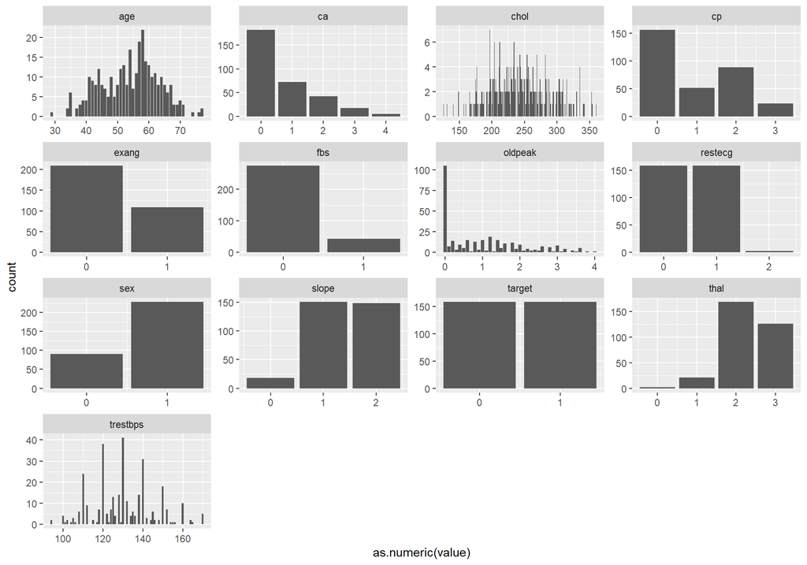

```r
# plot histograms of all variables to see how they are distributed
dataset %>%
  # gather columns into key value pairs
  gather() %>%
  # plot histogram with each graph having independent axes
  ggplot(aes(as.numeric(value))) + facet_wrap(~ key, scales = "free", ncol = 4) + geom_bar() +
  scale_x_continuous(breaks = function(x, n = 5) pretty(x, n)[pretty(x, n) %% 1 == 0] )
```

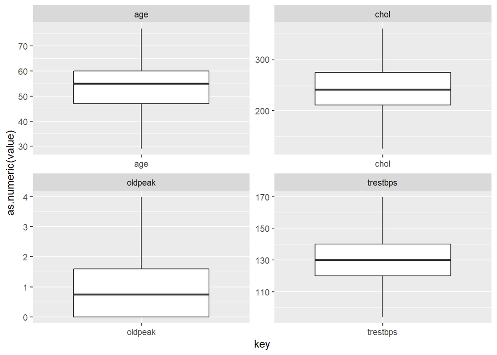

```r
# plot boxplot of all numeric variables to see how their values are distributed
dataset[, num.vars] %>%
  # gather columns into key value pairs
  gather() %>%
  # generate boxplot with each graph having independent axes
  ggplot(aes(key, as.numeric(value))) + facet_wrap(~ key, scales = "free") + geom_boxplot()
```

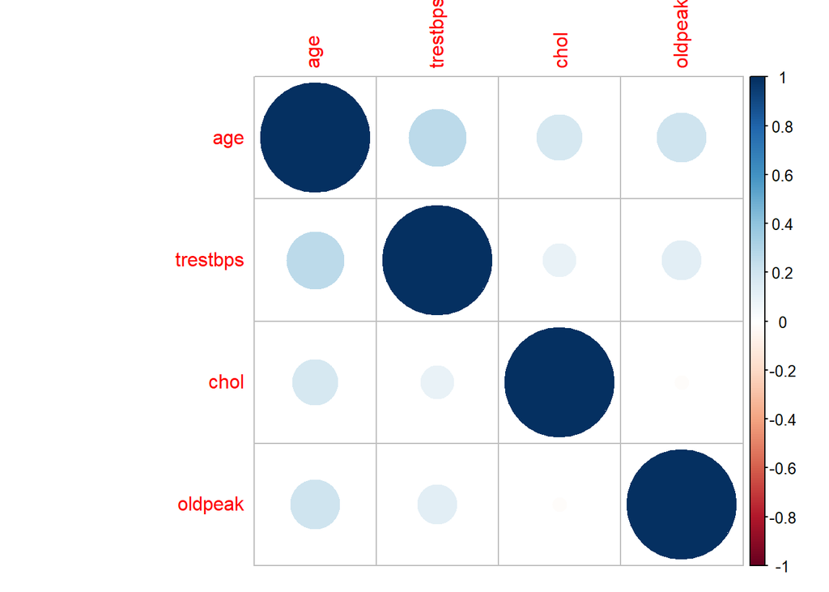

```r
# correlation plot
corrdata <- cor(dataset[, num.vars])
corrplot(corrdata)
```

```r
# correlation values
round(cor(dataset[, num.vars]), 2)
```

```
##           age trestbps  chol oldpeak
## age      1.00     0.27  0.17    0.20
## trestbps 0.27     1.00  0.09    0.13
## chol     0.17     0.09  1.00   -0.02
## oldpeak  0.20     0.13 -0.02    1.00
```

The data distribution is now balanced and free of outliers or multicollinearity. We have treated our data and we are ready for performing the further analyses.

# Exploratory data analysis

### Ocurrance of heart disease by variables

To understand how occurrance of heart disease varies with different variables, we will form hypotheses at variable level and test them one by one.

#### Age

We know that age age increases, risk of heart disease goes up. That essentially means, age distribution among those who have heart disease is significantly different than that among those who don’t have a heart disease. And also, we expect the ages to be higher in target = 0 compared to target = 1 (recall that target = 0 is presence of heart disease and 1 is the opposite).

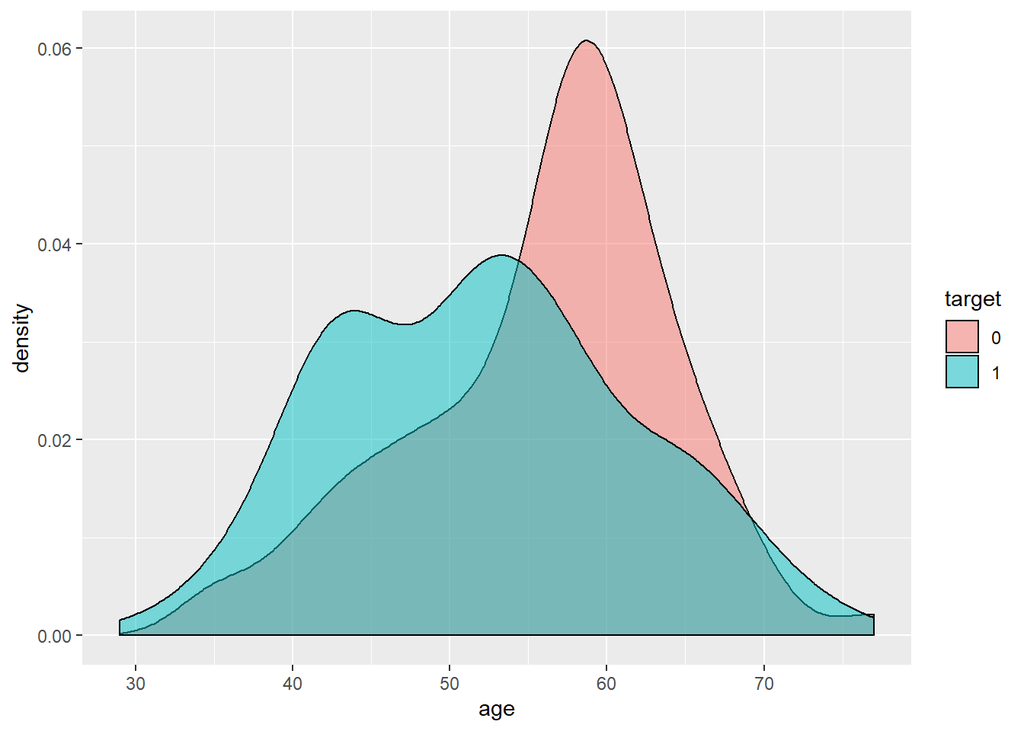

```r
ggplot(dataset, aes(x = age, fill = target)) + geom_density(alpha=0.5)
```

We can see that the distributions of age look quite different. In fact, it is exactly what we assumed initially - probability of ocurrance of heart disease is higher in old age.

```r
t.test(dataset$age[which(dataset$target == 0)], dataset$age[which(dataset$target == 1)])
```

```
##
##  Welch Two Sample t-test
##
## data:  dataset$age[which(dataset$target == 0)] and dataset$age[which(dataset$target == 1)]
## t = 3.8868, df = 310.3, p-value = 0.0001242
## alternative hypothesis: true difference in means is not equal to 0
## 95 percent confidence interval:
##  1.922287 5.863877
## sample estimates:
## mean of x mean of y
##  56.05031  52.15723
```

We reject the null hypothesis that the two age distributions are the same and can conclude that they are different. We can also conclude that the probability of encountering heart disease is higher in old age.

#### Gender

Various sources (like https://wa.kaiserpermanente.org/healthAndWellness/index.jhtml?item=/common/healthAndWellness/conditions/heartDisease/ageAndGender.html) say that the risk of heart disease is higher for men compared to women. Let’s see what our data says about that (sex = 1 means male and sex = 0 means female).

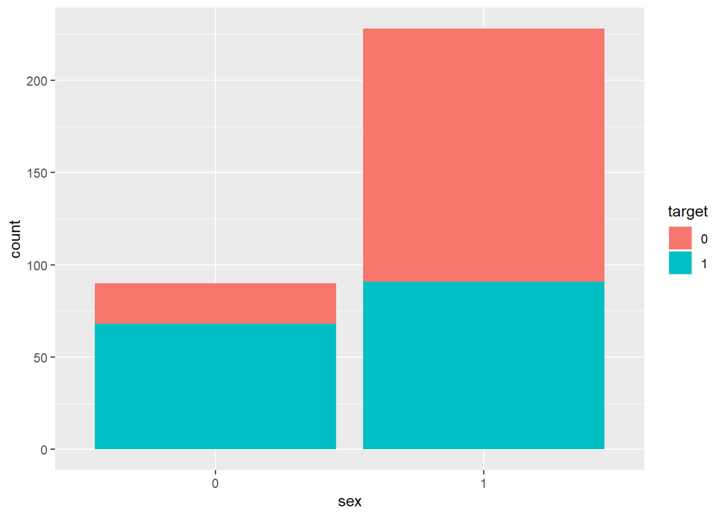

```r
ggplot(dataset, aes(x = sex, fill = target)) + geom_bar()
```

Let’s do a significance test for that.

```r
chisq.test(dataset$sex, dataset$target)
```

```
##
##  Pearson's Chi-squared test with Yates' continuity correction
##
## data:  dataset$sex and dataset$target
## X-squared = 31.382, df = 1, p-value = 2.12e-08
```

The p-value is extremely low for our significance level of 5%. So, the test says that gender and terget are heavily dependent on each other, or in other words, sex significantly matters in the occurrance of heart disease.

An interesting thing to do here would be to combine age and gender.

#### Age and gender combined

The source mentioned above also says that men develop heart disease at an early age compared to women. Let’s check that in our data.

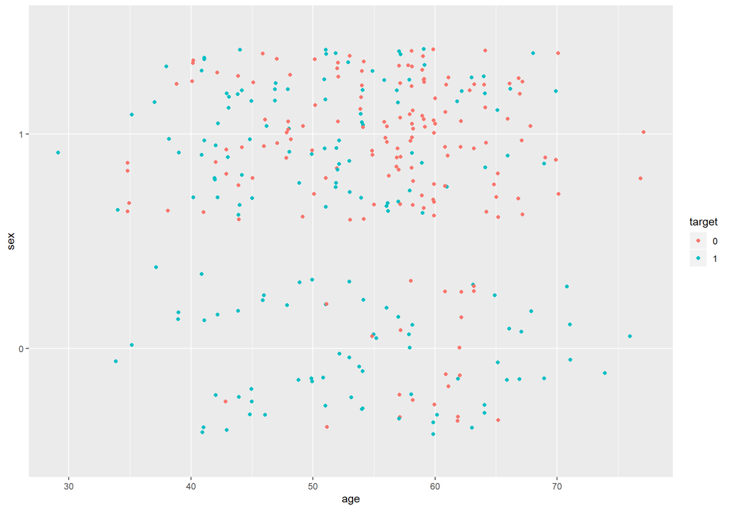

```r
ggplot(dataset, aes(x= age, y = sex, colour=target)) + geom_jitter(width = 0.2)
```

From the above graph, it is very clear that age ranges for heart disease occurrance are very different for the two genders.

If we look at sex = 0 row, we can see that blue points are quite evenly distributed across age but the orange points are more distributed between 55 to 65. That means, occurrance of heart disease is common in aged females and not in youth.

On the other hand, for males, both the types of points are evenly distributed across age. This means, young as well as old males are prone to heart disease. The results are in line with our assumption that men develop heart disease more than women and the risk is no less at an early age.

#### Blood pressure

A very interesting variable to look at will be (resting) blood pressure as risk of heart disease is positively associated with blood pressure. Ideally, we should see high blood pressure in patients with heart disease. Let’s check if the data says the same.

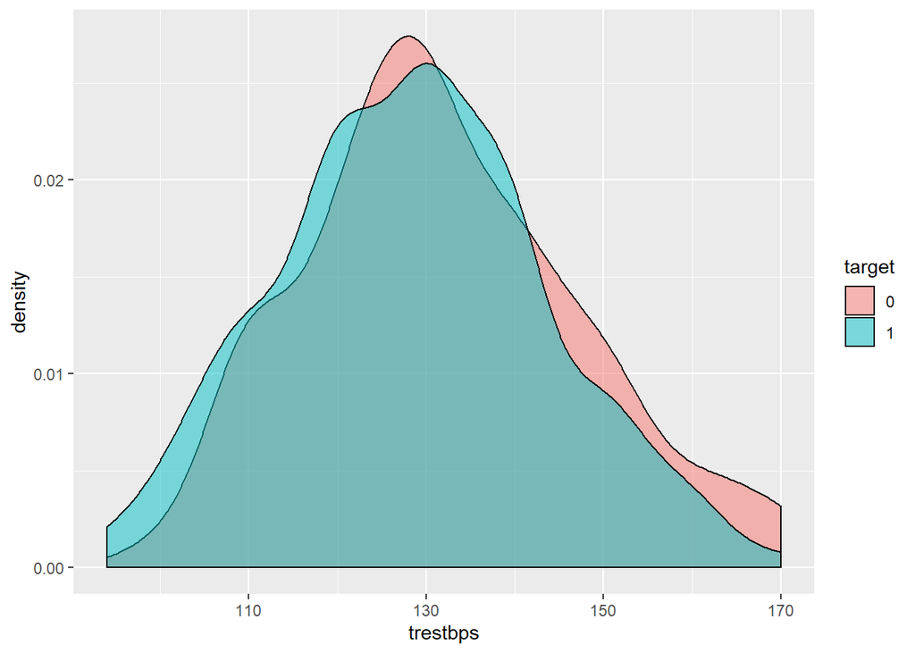

```r
ggplot(dataset, aes(x = trestbps, fill = target)) + geom_density(alpha = 0.5)
```

Though we see target = 0 on slight right side of target = 1, it is not clear whether these two distributions are essentially different. Let’s verify that with t t-test.

```r
t.test(dataset$trestbps[which(dataset$target == 0)], dataset$trestbps[which(dataset$target == 1)])
```

```
##
##  Welch Two Sample t-test
##
## data:  dataset$trestbps[which(dataset$target == 0)] and dataset$trestbps[which(dataset$target == 1)]
## t = 2.0831, df = 315.7, p-value = 0.03805
## alternative hypothesis: true difference in means is not equal to 0
## 95 percent confidence interval:
##  0.1975407 6.9219561
## sample estimates:
## mean of x mean of y
##  131.9245  128.3648
```

#### Chest pain (angina)

Another very interesting variable to look at would be chest pain. Heart and chest pains are very closely related. But the main thing to know here would be what type of chest pain is stronger indicator of heart disease.

(cp: 0 = typical angina; 1 = atypical angina; 2 = non-anginal pain; 3 = asymptomatic)

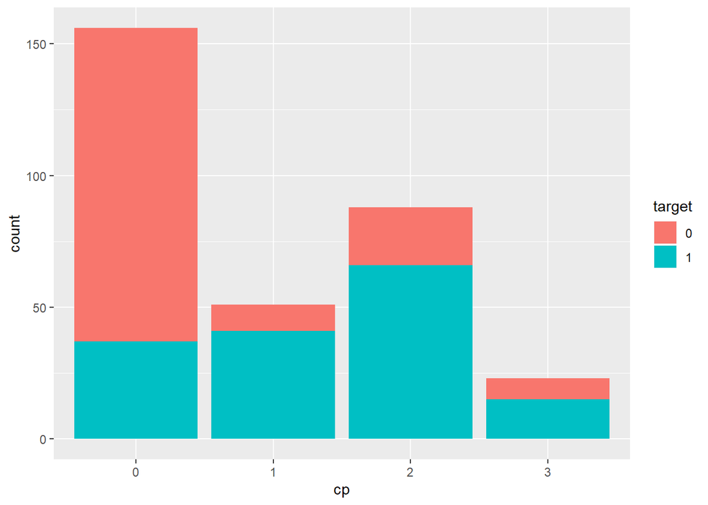

```r
ggplot(dataset, aes(x = cp, fill = target)) + geom_bar()
```

Let’s veryfy the dependence with a chi square test.

```r
chisq.test(dataset$cp, dataset$target)
```

```
##
##  Pearson's Chi-squared test
##
## data:  dataset$cp and dataset$target
## X-squared = 86.076, df = 3, p-value < 2.2e-16
```

The p-value is close to 0, which indicates a heavy dependence between chest pain type and heart disease.

#### Cholestoral

Cholestoral is probably the most talked about health term with people being superconscious about their cholestoral levels. This is because cholestoral is very highly associated with ocurrance of heart disease.

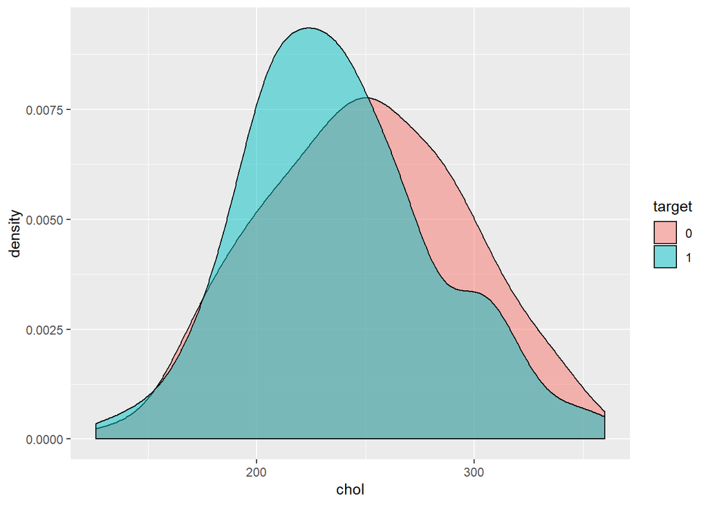

```r
ggplot(dataset, aes(x = chol, fill = target)) + geom_density(alpha = 0.5)
```

And, as expected, higher cholestrol is associated with heart disease. Let’s verify that statistically.

```r
t.test(dataset$chol[which(dataset$target == 0)], dataset$chol[which(dataset$target == 1)])
```

```
##
##  Welch Two Sample t-test
##
## data:  dataset$chol[which(dataset$target == 0)] and dataset$chol[which(dataset$target == 1)]
## t = 2.3229, df = 314.8, p-value = 0.02082
## alternative hypothesis: true difference in means is not equal to 0
## 95 percent confidence interval:
##   1.794402 21.664717
## sample estimates:
## mean of x mean of y
##  249.4591  237.7296
```

#### Blood sugar

Similar to the previous parts, we will test if blood sugar (fasting blood sugar > 120 mg/dl - 1 = true and 0 = false) determines presence of heart disease.

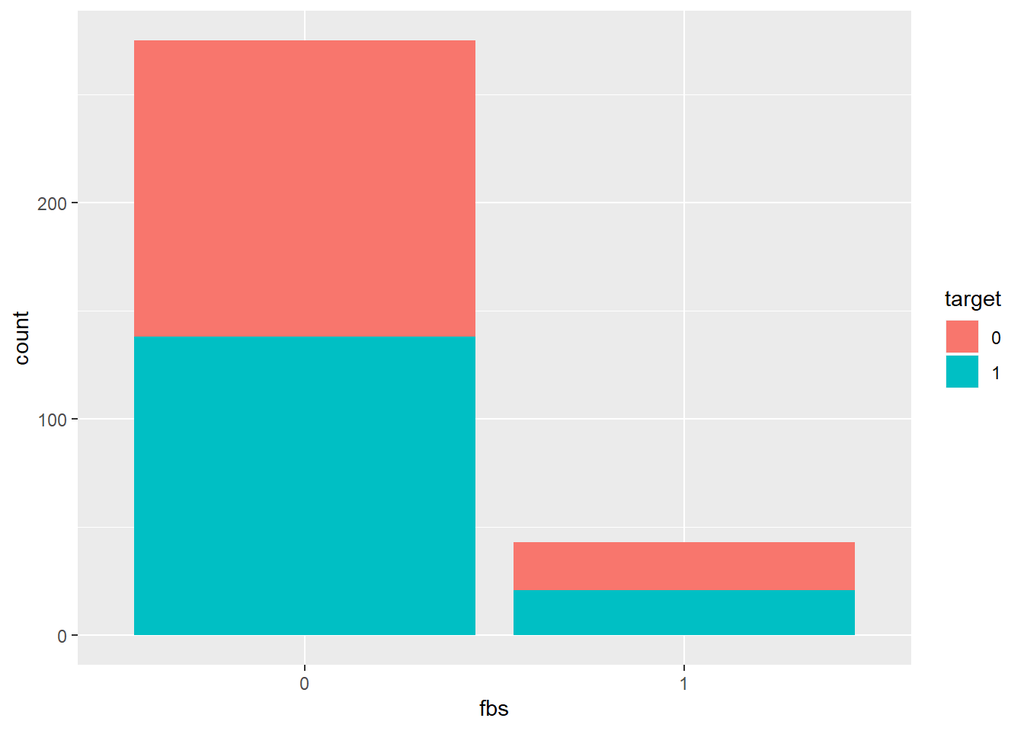

```r
ggplot(dataset, aes(x = fbs, fill = target)) + geom_bar()
```

```r
chisq.test(dataset$fbs, dataset$target)
```

```
##
##  Pearson's Chi-squared test with Yates' continuity correction
##
## data:  dataset$fbs and dataset$target
## X-squared = 0, df = 1, p-value = 1
```

From both distribution and the significance test, we can see that fasting blood sugar actually doesn’t differ with heart disease.

#### Electrocardiographic results

Rest electrocardiographic results can be a good predictor of heart disease.

(We are ignoring restecg = 2 as it has only 2 ocurrances in the data)

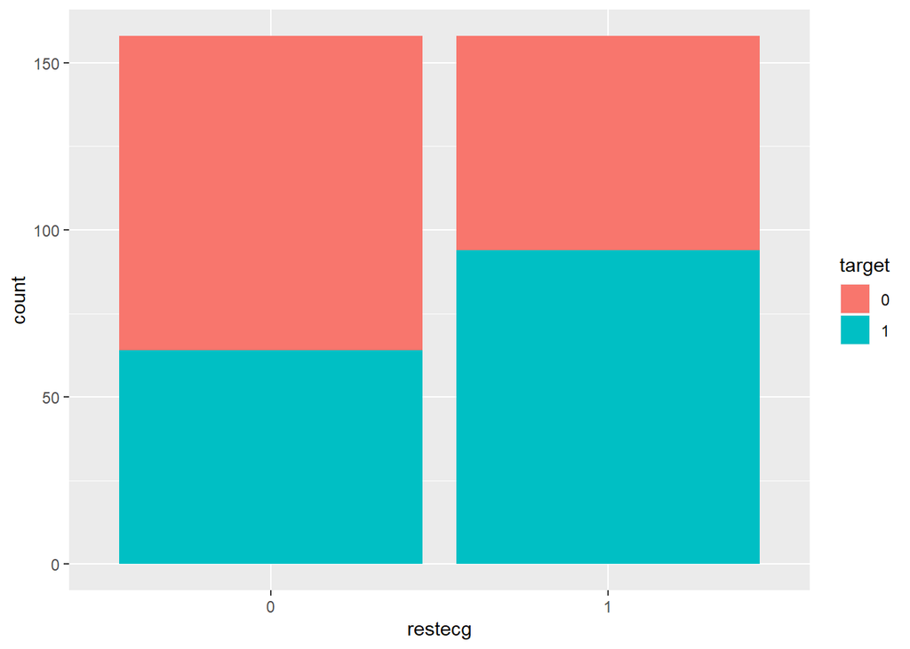

```r
ggplot(dataset[which(dataset$restecg != 2),], aes(x = restecg, fill = target)) + geom_bar()
```

```r
chisq.test(dataset[which(dataset$restecg != 2),]$restecg, dataset[which(dataset$restecg != 2),]$target)
```

```
##
##  Pearson's Chi-squared test with Yates' continuity correction
##
## data:  dataset[which(dataset$restecg != 2), ]$restecg and dataset[which(dataset$restecg != 2), ]$target
## X-squared = 10.646, df = 1, p-value = 0.001103
```

ECG results is indeed a good predictor.

#### Exercise induced angina

From previous results, we know that angina (chest pain) is a good predictor of heart disease. Let’s see if the same holds true for induced angina (exang: 1 = yes; 0 = no).

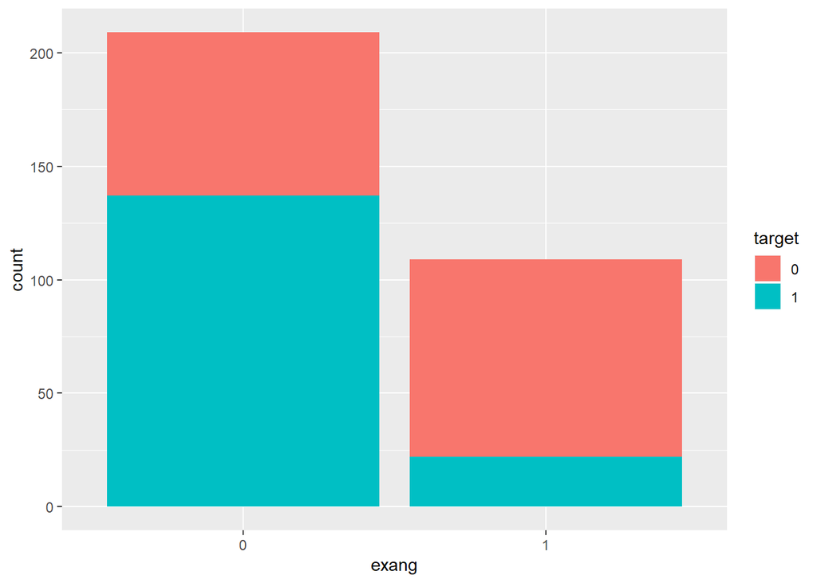

```r
ggplot(dataset, aes(x = exang, fill = target)) + geom_bar()
```

```r
chisq.test(dataset$exang, dataset$target)
```

```
##
##  Pearson's Chi-squared test with Yates' continuity correction
##
## data:  dataset$exang and dataset$target
## X-squared = 57.176, df = 1, p-value = 3.985e-14
```

As expected, induced angina is also a good predictor of heart disease.

#### ST depression

ST depression is stress test to check the heart health. It occurs when J point displaces below the baseline on the ecg, and represents myocardial ischemia or an emergent condition of heart disease. ST depression level, ideally, should be strongly associated with heart disease.

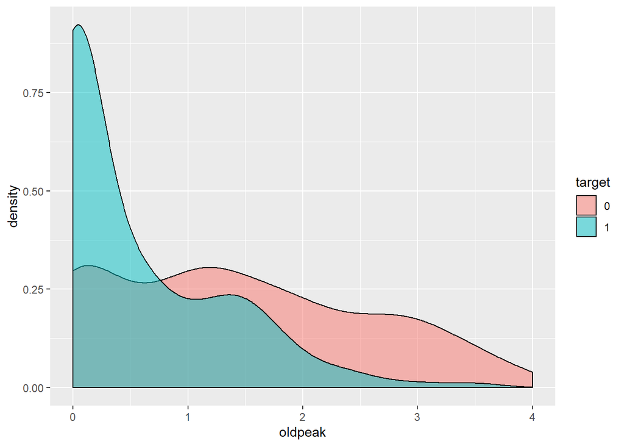

```r
ggplot(dataset, aes(x = oldpeak, fill = target)) + geom_density(alpha = 0.5)
```

```r
t.test(dataset$oldpeak[which(dataset$target == 0)], dataset$oldpeak[which(dataset$target == 1)])
```

```
##
##  Welch Two Sample t-test
##
## data:  dataset$oldpeak[which(dataset$target == 0)] and dataset$oldpeak[which(dataset$target == 1)]
## t = 8.0048, df = 271.25, p-value = 3.524e-14
## alternative hypothesis: true difference in means is not equal to 0
## 95 percent confidence interval:
##  0.6440272 1.0641489
## sample estimates:
## mean of x mean of y
## 1.4069182 0.5528302
```

Higher ST depression measuring relates to occurrance of heart disease and ST depression in itself is a strong indicator of heart disease with p-value close to 0.

#### Peak exercise ST segment

A stress test (slope: 0 = upsloping; 1 = flat; 2 = downsloping) can determine the risk of having heart disease. A treadmill ECG stress test is considered abnormal when there is a flat or down-sloping ST-segment depression. (Reference: https://www.webmd.com/heart-disease/guide/stress-test#1).

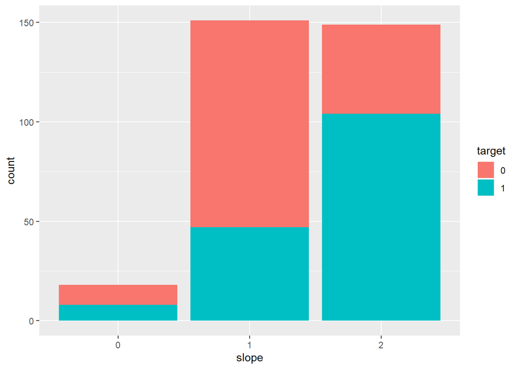

```r
ggplot(dataset, aes(x = slope, fill = target)) + geom_bar()
```

```r
chisq.test(dataset$slope, dataset$target)
```

```
##
##  Pearson's Chi-squared test
##
## data:  dataset$slope and dataset$target
## X-squared = 45.101, df = 2, p-value = 1.608e-10
```

#### Thalassemia

Thalassemia (thal: 1 = normal; 2 = fixed defect; 3 = reversable defect) is a blood disorder and it is an indicator of possibility of heart disease. We are ignoring thal = 0 here because it is unknown in our data.

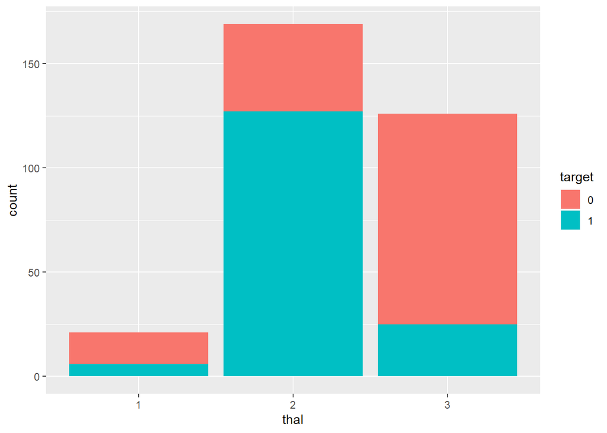

```r
ggplot(dataset[which(dataset$thal != 0),], aes(x = thal, fill = target)) + geom_bar()
```

```r
chisq.test(dataset[which(dataset$thal != 0),]$thal, dataset[which(dataset$thal != 0),]$target)
```

```
##
##  Pearson's Chi-squared test
##
## data:  dataset[which(dataset$thal != 0), ]$thal and dataset[which(dataset$thal != 0), ]$target
## X-squared = 92.45, df = 2, p-value < 2.2e-16
```

It can be seen that thalassemia is a strong predictor of heart disease with p-value close to 0 and reversible defect denotes presence of heart disease.

#### Major blood vessels

Though, the meaning if this variable is not clear from the data description on Kaggle as well as anywhere else on internet, we will just see how it performs. There are 5 major blood vessels in human body. But which one is denoted by which number in the data is not clear to us.

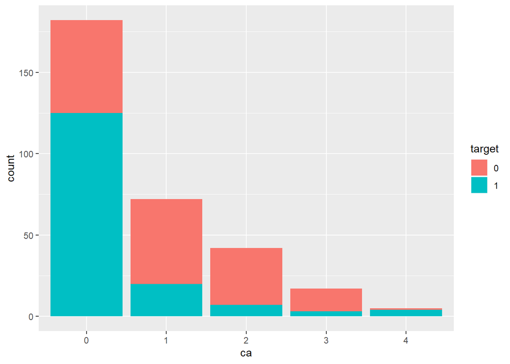

```r
ggplot(dataset, aes(x = ca, fill = target)) + geom_bar()
```

```r
chisq.test(dataset$ca, dataset$target)
```

```
##
##  Pearson's Chi-squared test
##
## data:  dataset$ca and dataset$target
## X-squared = 67.213, df = 4, p-value = 8.79e-14
```

The variable has significant association with heart disease, and, except for 0th and 4th blood vessels, heart disease rate is high in the blood vessels colored by flourosopy.

### Conclusion of EDA

From the exploratory data analysis, we can conclude that the 14 variables included in the data (out of 76 total) are a very good set of predictors. We can build some good models to predict the risk of heart disease.

# Classification models

With such strong predictors, there will be numerous models that can be trained with the data to predict the risk of ocurrance of heart disease. But we will look at some key models which are highly relevant.

### Training and testing data

```r
sample = sample.split(dataset, SplitRatio = 0.8)
train =subset(dataset, sample == TRUE)
test =subset(dataset, sample == FALSE)
summary(train)
```

```
##       age        sex     cp         trestbps          chol       fbs
##  Min.   :34.00   0: 71   0:120   Min.   : 94.0   Min.   :126.0   0:213
##  1st Qu.:46.00   1:173   1: 42   1st Qu.:120.0   1st Qu.:211.0   1: 31
##  Median :55.00           2: 60   Median :130.0   Median :241.0
##  Mean   :54.07           3: 22   Mean   :129.5   Mean   :244.4
##  3rd Qu.:60.00                   3rd Qu.:140.0   3rd Qu.:273.2
##  Max.   :77.00                   Max.   :170.0   Max.   :360.0
##  restecg exang      oldpeak       slope   ca      thal    target
##  0:116   0:161   Min.   :0.0000   0: 16   0:144   0:  1   0:117
##  1:127   1: 83   1st Qu.:0.0000   1:124   1: 58   1: 17   1:127
##  2:  1           Median :0.7000   2:104   2: 28   2:132
##                  Mean   :0.9959           3: 10   3: 94
##                  3rd Qu.:1.6000           4:  4
##                  Max.   :3.8000
```

```r
summary(test)
```

```
##       age        sex    cp        trestbps          chol       fbs
##  Min.   :29.00   0:19   0:36   Min.   : 94.0   Min.   :141.0   0:62
##  1st Qu.:48.25   1:55   1: 9   1st Qu.:124.2   1st Qu.:210.2   1:12
##  Median :56.50          2:28   Median :130.0   Median :239.0
##  Mean   :54.23          3: 1   Mean   :132.2   Mean   :241.0
##  3rd Qu.:60.75                 3rd Qu.:141.5   3rd Qu.:277.8
##  Max.   :77.00                 Max.   :164.0   Max.   :330.0
##  restecg exang     oldpeak      slope  ca     thal   target
##  0:42    0:48   Min.   :0.000   0: 2   0:38   0: 1   0:42
##  1:31    1:26   1st Qu.:0.000   1:27   1:14   1: 4   1:32
##  2: 1           Median :0.750   2:45   2:14   2:37
##                 Mean   :0.927          3: 7   3:32
##                 3rd Qu.:1.600          4: 1
##                 Max.   :4.000
```

Training data has **244** rows and test data has **74** rows.

### Logistic regression

With strong categorical predictors for classification, logistic regression can be a good choice for classification.

```r
logistic.model <- glm(target ~ ., data = train, family = "binomial")
summary(logistic.model)
```

```
##
## Call:
## glm(formula = target ~ ., family = "binomial", data = train)
##
## Deviance Residuals:
##     Min       1Q   Median       3Q      Max
## -2.4175  -0.3770   0.0792   0.4238   3.0769
##
## Coefficients:
##               Estimate Std. Error z value Pr(>|z|)
## (Intercept) -6.385e+00  1.455e+03  -0.004 0.996499
## age          1.730e-03  2.579e-02   0.067 0.946517
## sex1        -1.626e+00  6.218e-01  -2.615 0.008912 **
## cp1          1.090e+00  6.464e-01   1.687 0.091646 .
## cp2          1.808e+00  6.570e-01   2.752 0.005927 **
## cp3          2.396e+00  7.547e-01   3.174 0.001503 **
## trestbps    -3.759e-02  1.491e-02  -2.522 0.011675 *
## chol        -9.631e-03  5.431e-03  -1.773 0.076191 .
## fbs1         6.913e-01  7.088e-01   0.975 0.329430
## restecg1     4.549e-01  4.602e-01   0.988 0.322956
## restecg2     1.224e+01  1.455e+03   0.008 0.993287
## exang1      -9.416e-01  5.257e-01  -1.791 0.073298 .
## oldpeak     -5.925e-01  2.925e-01  -2.025 0.042836 *
## slope1      -4.799e-01  8.994e-01  -0.534 0.593582
## slope2       9.347e-01  9.973e-01   0.937 0.348661
## ca1         -2.639e+00  5.885e-01  -4.485  7.3e-06 ***
## ca2         -3.267e+00  9.198e-01  -3.552 0.000382 ***
## ca3         -1.131e+00  1.047e+00  -1.080 0.280223
## ca4          7.756e-01  1.718e+00   0.451 0.651672
## thal1        1.547e+01  1.455e+03   0.011 0.991522
## thal2        1.606e+01  1.455e+03   0.011 0.991196
## thal3        1.425e+01  1.455e+03   0.010 0.992191
## ---
## Signif. codes:  0 '***' 0.001 '**' 0.01 '*' 0.05 '.' 0.1 ' ' 1
##
## (Dispersion parameter for binomial family taken to be 1)
##
##     Null deviance: 337.85  on 243  degrees of freedom
## Residual deviance: 151.25  on 222  degrees of freedom
## AIC: 195.25
##
## Number of Fisher Scoring iterations: 14
```

Let’s test the model on the test data.

```r
logistic.probabilities <- predict(logistic.model, newdata = test, type="response")
# convert probabilities into predictions. 1 if >= 0.5 and 0 if < 0.5
logistic.predictions <- as.factor(ifelse(logistic.probabilities >= 0.5, 1, 0))
confusionMatrix(logistic.predictions, test$target)
```

```
## Confusion Matrix and Statistics
##
##           Reference
## Prediction  0  1
##          0 33  2
##          1  9 30
##
##                Accuracy : 0.8514
##                  95% CI : (0.7496, 0.9234)
##     No Information Rate : 0.5676
##     P-Value [Acc > NIR] : 1.686e-07
##
##                   Kappa : 0.7049
##
##  Mcnemar's Test P-Value : 0.07044
##
##             Sensitivity : 0.7857
##             Specificity : 0.9375
##          Pos Pred Value : 0.9429
##          Neg Pred Value : 0.7692
##              Prevalence : 0.5676
##          Detection Rate : 0.4459
##    Detection Prevalence : 0.4730
##       Balanced Accuracy : 0.8616
##
##        'Positive' Class : 0
##
```

The confusion matrix says that the model is 85% accurate. 33 out of 42 occurrances of heart disease were predicted correctly by the model, and 30 out of 32 non-ocurrances of heart disease were predicted accurately.

### Decision trees

When we have many categorical predictors, decision trees come handy at leading us to some good classification rules.

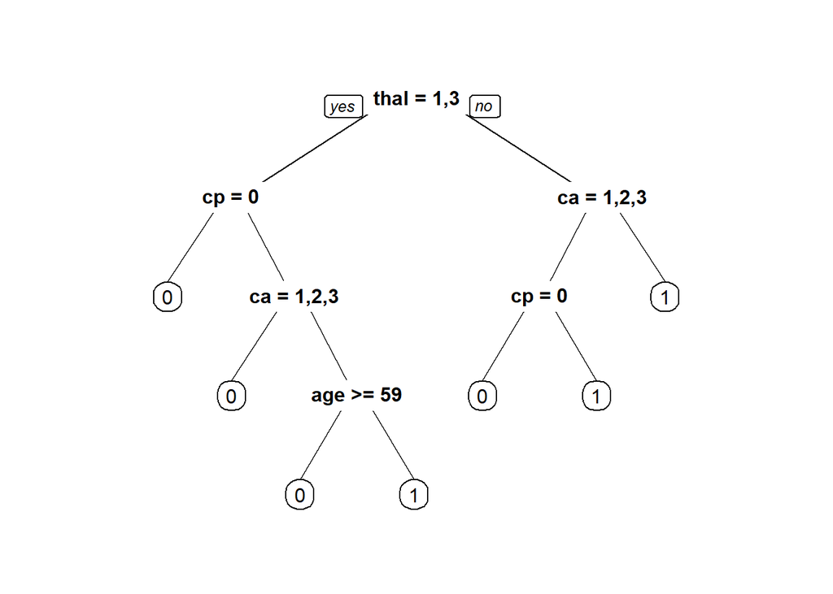

```r
dt.model <- rpart(target ~ ., data=dataset)
prp(dt.model)
```

Validation:

```r
dt.predictions <- predict(dt.model, newdata = test, type = "class")
confusionMatrix(dt.predictions, test$target)
```

```
## Confusion Matrix and Statistics
##
##           Reference
## Prediction  0  1
##          0 36  2
##          1  6 30
##
##                Accuracy : 0.8919
##                  95% CI : (0.798, 0.9522)
##     No Information Rate : 0.5676
##     P-Value [Acc > NIR] : 1.267e-09
##
##                   Kappa : 0.783
##
##  Mcnemar's Test P-Value : 0.2888
##
##             Sensitivity : 0.8571
##             Specificity : 0.9375
##          Pos Pred Value : 0.9474
##          Neg Pred Value : 0.8333
##              Prevalence : 0.5676
##          Detection Rate : 0.4865
##    Detection Prevalence : 0.5135
##       Balanced Accuracy : 0.8973
##
##        'Positive' Class : 0
##
```

The accuracy achieved is 89% with 36 out of 42 ocurrances being predicted accurately and 30 out of 32 non-occurrances being predicted correctly.

### Random forest

The decision tree we built above can be prone to overfitting and also, the random state the program currently is in. In such cases, an ensemble model like like random forest can yield more accurate and unbiased results.

Let’s try building a random forest model with 100 decision trees.

```r
rf.model <- randomForest(target ~ ., data=dataset, ntree = 100)
summary(rf.model)
```

```
##                 Length Class  Mode
## call              4    -none- call
## type              1    -none- character
## predicted       318    factor numeric
## err.rate        300    -none- numeric
## confusion         6    -none- numeric
## votes           636    matrix numeric
## oob.times       318    -none- numeric
## classes           2    -none- character
## importance       12    -none- numeric
## importanceSD      0    -none- NULL
## localImportance   0    -none- NULL
## proximity         0    -none- NULL
## ntree             1    -none- numeric
## mtry              1    -none- numeric
## forest           14    -none- list
## y               318    factor numeric
## test              0    -none- NULL
## inbag             0    -none- NULL
## terms             3    terms  call
```

Let’s check the model performance on the test data.

```r
rf.predictions <- predict(rf.model, newdata = test, type = "class")
confusionMatrix(rf.predictions, test$target)
```

```
## Confusion Matrix and Statistics
##
##           Reference
## Prediction  0  1
##          0 41  0
##          1  1 32
##
##                Accuracy : 0.9865
##                  95% CI : (0.927, 0.9997)
##     No Information Rate : 0.5676
##     P-Value [Acc > NIR] : <2e-16
##
##                   Kappa : 0.9726
##
##  Mcnemar's Test P-Value : 1
##
##             Sensitivity : 0.9762
##             Specificity : 1.0000
##          Pos Pred Value : 1.0000
##          Neg Pred Value : 0.9697
##              Prevalence : 0.5676
##          Detection Rate : 0.5541
##    Detection Prevalence : 0.5541
##       Balanced Accuracy : 0.9881
##
##        'Positive' Class : 0
##
```

With that, we can use random forest as a trustworthy model for predicting the risk of heart disease.

### Conclusion of classification exercise

We built 3 classifier models on the data we have. Random Forest turned out to be an effective classifier.

# Final remarks

In thie project, we took a shot at crunching the data and doing some analysis on D=Cleveland heart disease data. We first performed basic data treatments, then we did some EDA to verify that the predictors we are including really make sense and finally, we built 3 classifiers.

Of course, this is just a stepping stone into the field of data analytics. This analysis can be enhanced further with the help of other advanced classification techniques and validation methodologies like k-fold cross validation.